# Final Project

OVERALL QUESTION I AM TRYING TO ANSWER: Does age have an impact on WHERE people shop (ie. online, in store, through a catalog)

Necessary Imports

```r
library(ggplot2)
library(e1071)
library(dplyr)
```

First I am reading in the CSV file.

```r
data <- read.csv("~/Desktop/INFO_659/final_project/marketing_campaign.csv")
head(data)
```

|  | ID | Year_Birth | Education | Marital_Status | Income | Kidhome | Teenhome | Dt_Customer | Recency | MntWines | MntFruits | MntMeatProducts | MntFishProducts | MntSweetProducts | MntGoldProds | NumDealsPurchases | NumWebPurchases | NumCatalogPurchases | NumStorePurchases | NumWebVisitsMonth | AcceptedCmp3 | AcceptedCmp4 | AcceptedCmp5 | AcceptedCmp1 | AcceptedCmp2 | Complain | Z_CostContact | Z_Revenue | Response |
| --- | --- | --- | --- | --- | --- | --- | --- | --- | --- | --- | --- | --- | --- | --- | --- | --- | --- | --- | --- | --- | --- | --- | --- | --- | --- | --- | --- | --- | --- |
| 1 | 5524 | 1957 | Graduation | Single | 58138 | 0 | 0 | 4/9/12 | 58 | 635 | 88 | 546 | 172 | 88 | 88 | 3 | 8 | 10 | 4 | 7 | 0 | 0 | 0 | 0 | 0 | 0 | 3 | 11 | 1 |
| 2 | 2174 | 1954 | Graduation | Single | 46344 | 1 | 1 | 8/3/14 | 38 | 11 | 1 | 6 | 2 | 1 | 6 | 2 | 1 | 1 | 2 | 5 | 0 | 0 | 0 | 0 | 0 | 0 | 3 | 11 | 0 |
| 3 | 4141 | 1965 | Graduation | Together | 71613 | 0 | 0 | 21-08-2013 | 26 | 426 | 49 | 127 | 111 | 21 | 42 | 1 | 8 | 2 | 10 | 4 | 0 | 0 | 0 | 0 | 0 | 0 | 3 | 11 | 0 |
| 4 | 6182 | 1984 | Graduation | Together | 26646 | 1 | 0 | 10/2/14 | 26 | 11 | 4 | 20 | 10 | 3 | 5 | 2 | 2 | 0 | 4 | 6 | 0 | 0 | 0 | 0 | 0 | 0 | 3 | 11 | 0 |
| 5 | 5324 | 1981 | PhD | Married | 58293 | 1 | 0 | 19-01-2014 | 94 | 173 | 43 | 118 | 46 | 27 | 15 | 5 | 5 | 3 | 6 | 5 | 0 | 0 | 0 | 0 | 0 | 0 | 3 | 11 | 0 |
| 6 | 7446 | 1967 | Master | Together | 62513 | 0 | 1 | 9/9/13 | 16 | 520 | 42 | 98 | 0 | 42 | 14 | 2 | 6 | 4 | 10 | 6 | 0 | 0 | 0 | 0 | 0 | 0 | 3 | 11 | 0 |

Now I am checking the data for null values.

```r
is.null(data)
```

```
## [1] FALSE
```

Now that we know the data doesn’t contain any nulls, we can move forward.

First I will be creating an ‘age’ variable which takes the year a customer was born and subtracts that from 2021 to get the customers age.

```r
data$age <- 2021 - data['Year_Birth']
data$age <- as.numeric(unlist(data$age))
```

Now I will create a histogram of the age data to get a better understanding of the customers on this data set.

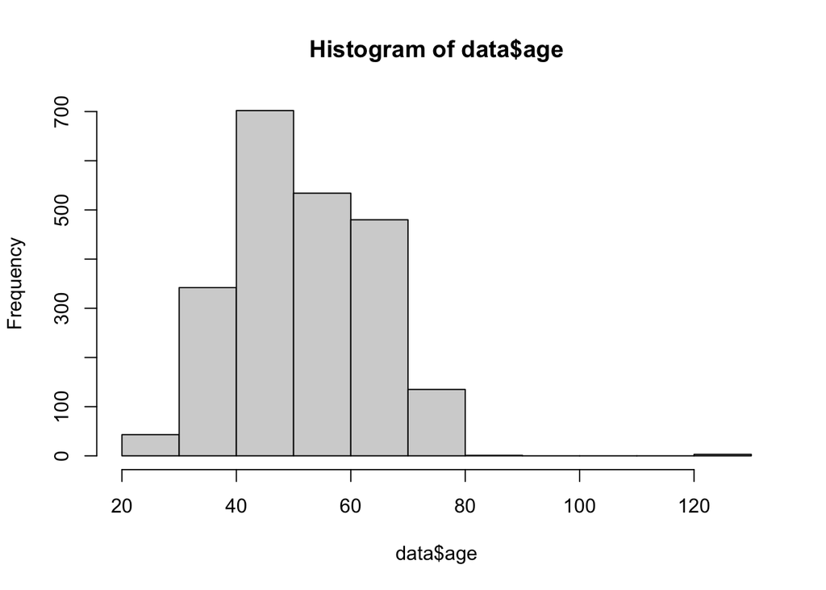

```r
hist(data$age)
```

```r
data <- within(data, {
  ageCat <- NA # need to initialize variable
  ageCat[age < 35] <- "20-35"
  ageCat[age >= 35 & age < 50] <- "35-49"
  ageCat[age >= 50 & age < 65] <- "50-64"
  ageCat[age >= 65] <- "65+"
   } )

head(data$ageCat)
```

```
## [1] "50-64" "65+"   "50-64" "35-49" "35-49" "50-64"
```

Next, I am looking at the frequency of where each age group tends to make their purchases.

```r
xtabs(~ageCat+NumWebPurchases, data = data)
```

```
##        NumWebPurchases
## ageCat    0   1   2   3   4   5   6   7   8   9  10  11  23  25  27
##   20-35   3  31  24  32  21  14   9   4   4   2   1   2   0   0   0
##   35-49  24 161 166 133  90  72  67  62  32  19  12  14   0   0   1
##   50-64  16 117 130 115 107  94  71  49  47  33  20  16   1   1   0
##   65+     6  45  53  56  62  40  58  40  19  21  10  12   0   0   1
```

```r
xtabs(~ageCat+NumCatalogPurchases, data = data)
```

```
##        NumCatalogPurchases
## ageCat    0   1   2   3   4   5   6   7   8   9  10  11  22  28
##   20-35  47  25  10   6  18   9   7   8   2   4   9   2   0   0
##   35-49 301 197  97  58  49  34  51  23  16   8  12   3   1   3
##   50-64 173 188 109  81  71  67  41  27  20  21  12   7   0   0
##   65+    65  87  60  39  44  30  29  21  17   9  15   7   0   0
```

```r
xtabs(~ageCat+NumStorePurchases, data = data)
```

```
##        NumStorePurchases
## ageCat    0   1   2   3   4   5   6   7   8   9  10  11  12  13
##   20-35   1   0  15  35  26   6  10  12   6   2  13   8   9   4
##   35-49   7   4 109 249 105  70  62  40  56  35  36  24  33  23
##   50-64   4   3  80 148 132  77  66  62  55  41  44  27  44  34
##   65+     3   0  19  58  60  59  40  29  32  28  32  22  19  22
```

Now I am graphing each of these variables against age to visually see what is going on.

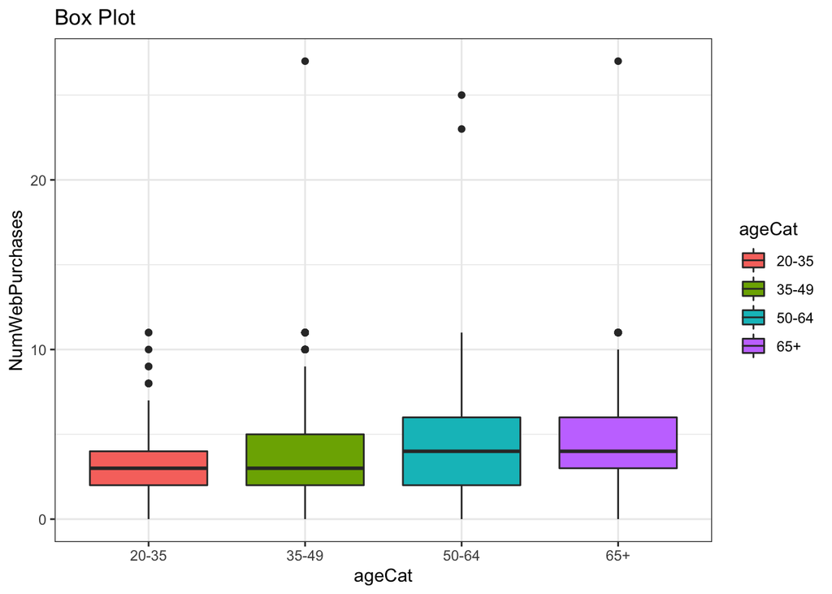

```r
data %>%
  ggplot(aes(x=ageCat, y=NumWebPurchases, fill = ageCat)) +
  geom_boxplot() +theme_bw()+
  ggtitle("Box Plot")
```

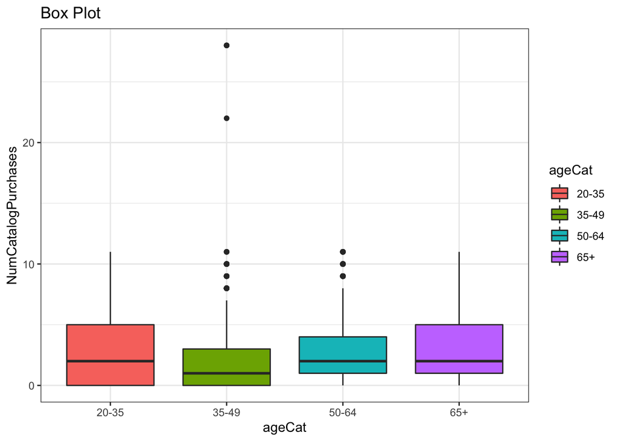

```r
data %>%
         ggplot(aes(x=ageCat, y=NumCatalogPurchases, fill = ageCat)) +
         geom_boxplot() +theme_bw()+
         ggtitle("Box Plot")
```

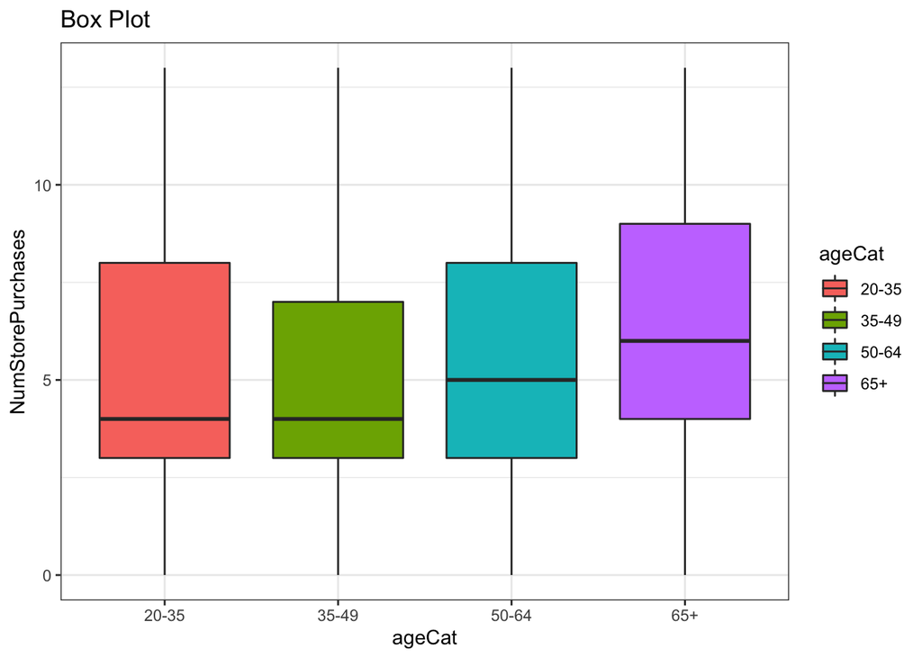

```r
data %>%
         ggplot(aes(x=ageCat, y=NumStorePurchases, fill = ageCat)) +
         geom_boxplot() +theme_bw()+
         ggtitle("Box Plot")
```

It seems as though each age group is pretty similar in their spending ways.

```r
#model <- naiveBayes(ageCat ~ NumWebPurchases + NumCatalogPurchases + NumStorePurchases, data = train, usekernel = T, laplace = 1.5)
#model
```